# DA 460 - Lab 5

Marjorie Blanco

29 July, 2018

# Handout 5 R: Foundations for statistical inference - Confidence intervals

## The data

```r
download.file("http://www.openintro.org/stat/data/ames.RData", destfile = "ames.RData")
load("ames.RData")
```

Simple random sample of size 60 for the size of the house, represented by the variable Gr.Liv.Area, from the population.

```r
# the ground living area
population <- ames$Gr.Liv.Area

summary(ames$Gr.Liv.Area)
```

```
##    Min. 1st Qu.  Median    Mean 3rd Qu.    Max.
##     334    1126    1442    1500    1743    5642
```

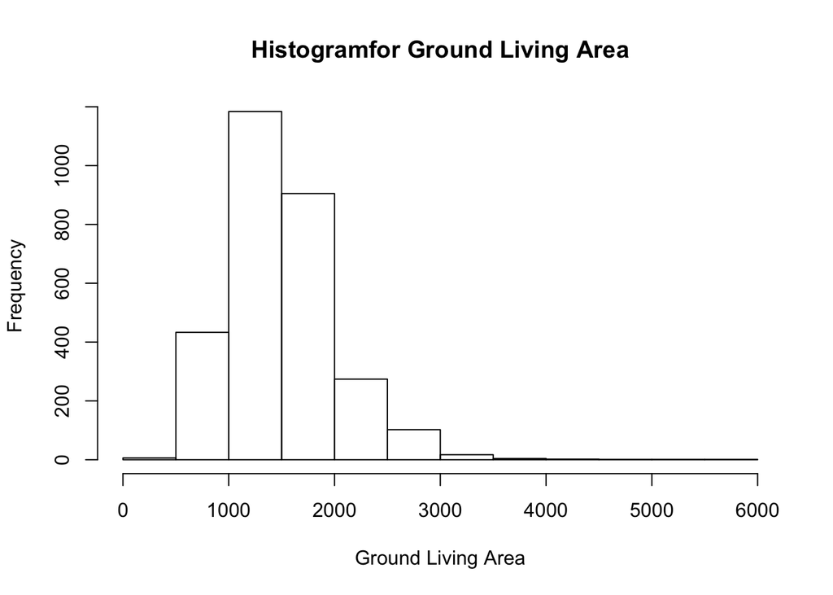

```r
hist(ames$Gr.Liv.Area, main = "Histogramfor Ground Living Area", xlab = "Ground Living Area")
```

```r
# simple random sample of size 60
samp <- sample(population, 60)
```

Confidence intervals at the confidence level 95% for Ames data set for the ground living area

```r
# varius way to get confidence intervals
t.test(ames$Gr.Liv.Area, alternative="two.sided", conf.level=0.95)
```

```
##
##  One Sample t-test
##
## data:  ames$Gr.Liv.Area
## t = 160.59, df = 2929, p-value < 2.2e-16
## alternative hypothesis: true mean is not equal to 0
## 95 percent confidence interval:
##  1481.379 1518.002
## sample estimates:
## mean of x
##   1499.69
```

```r
CI(ames$Gr.Liv.Area, ci=0.95)
```

```
##    upper     mean    lower
## 1518.002 1499.690 1481.379
```

```r
MeanCI(ames$Gr.Liv.Area, conf.level=0.95)
```

```
##     mean   lwr.ci   upr.ci
## 1499.690 1481.379 1518.002
```

### Exercise 1

Describe the distribution of your sample. What would you say is the “typical” size within your sample? Also state precisely what you interpreted “typical” to mean.

```r
summary(samp)
```

```
##    Min. 1st Qu.  Median    Mean 3rd Qu.    Max.
##     672    1268    1515    1703    1946    4676
```

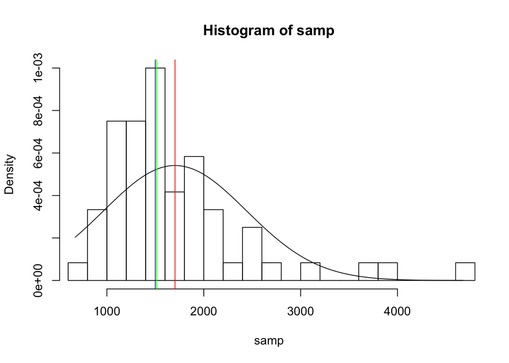

```r
xlimits <- range(samp)
hist(samp, breaks = 20, xlim = xlimits, prob=TRUE)
curve(dnorm(x, mean=mean(samp), sd=sd(samp)), add=TRUE)

# population mean
abline(v=mean(population), col="blue")
# sample mean
abline(v=mean(samp), col="red")
# sample mean
abline(v=median(samp), col="green")
```

The distribution for `samp` is unimodal, near normally distributed but right skewed. The median (1515) is less than the mean (1703.417). The standard deviation is 737.263. The “typical” to means that the typical sample mean would fall around the population mean. The “typical” size within a sample would fall near the population mean.

The data follow does follow a near normally distribution.

- Mean (red line): 1703.417
- Median (green line): 1515
- SD: 737.263

### Exercise 2

Would you expect another student’s distribution to be identical to yours? Would you expect it to be similar? Why or why not?

Another student’s distribution will not be idential but similar to mine as both samples are random sampling from the population (data set). I would expect the distribution to be similar (not exact) because then the sampling distribution of the point estimate (mean) should be centered.

## Confidence intervals

```r
sample_mean <- mean(samp)

se <- sd(samp) / sqrt(60)
lower <- sample_mean - qnorm(.975) * se
upper <- sample_mean + qnorm(.975) * se
c(lower, upper)
```

```
## [1] 1516.867 1889.966
```

```r
t.test(samp)
```

```
##
##  One Sample t-test
##
## data:  samp
## t = 17.897, df = 59, p-value < 2.2e-16
## alternative hypothesis: true mean is not equal to 0
## 95 percent confidence interval:
##  1512.962 1893.872
## sample estimates:
## mean of x
##  1703.417
```

```r
CI(samp, ci=0.95)
```

```
##    upper     mean    lower
## 1893.872 1703.417 1512.962
```

```r
MeanCI(samp, conf.level=0.95)
```

```
##     mean   lwr.ci   upr.ci
## 1703.417 1512.962 1893.872
```

### Exercise 3

For the confidence interval to be valid, the sample mean must be normally distributed and have standard error s/sqrt(n). What conditions must be met for this to be true?

For the confidence interval to be valid, the sample must be random and independent, the sample size should be greater than 30, and the disribution should be approximately normally distributed and not strongly skewed.

## Confidence levels

### Exercise 4

What does “95% confidence” mean? If you’re not sure, see Section 4.2.2.

After taking many samples and building a confidence interval from each sample then about 95% of those intervals would contain the actual mean. The confidence interval for the population parameter is point estimate ± z⋅SE where z is the confidence level selected.

```r
mean(population)
```

```
## [1] 1499.69
```

```r
mean(samp)
```

```
## [1] 1703.417
```

```r
c(lower, upper)
```

```
## [1] 1516.867 1889.966
```

### Exercise 5

Does your confidence interval capture the true average size of houses in Ames? If you are working on this lab in a classroom, does your neighbor’s interval capture this value?

### Exercise 6

Each student in your class should have gotten a slightly different confidence interval. What proportion of those intervals would you expect to capture the true population mean? Why?

I would expect 95% of the intervals would captue the true population mean, the remaining 5% will be due to a marging of error.